# Simple linear regression

Sue McClatchy

#### Learning Objectives

> - Load data from a URL.
> - Produce a scatterplot of data.
> - Build and plot a linear model.
> - Evaluate model quality and significance.

#### Introduction

Linear models can be helpful in describing the relationships between two or more variables. We’ll build linear models from a multi-system survey of mouse physiology in 8 inbred founder strains and 54 F1 hybrids of the Collaborative Cross. The study is described in Lenarcic AB, Svenson KL, Churchill GA, Valdar W. A general Bayesian approach to analyzing diallel crosses of inbred strains. Genetics. 2012 Feb;190(2):413-35.

#### Load data

Load the data from this shortened URL. Mind the double quotes.

```r
cc_data <- read.csv(file = "http://bit.ly/CGDpheno3")
```

#### Explore data

Explore the data variables. The first 4 columns contain strain, sex, and ID numbers. The remaining contain phenotype measurements with abbreviated names.

```r
names(cc_data)
```

```
##  [1] "strain"          "sex"             "id"
##  [4] "mouse_num"       "CHOL"            "HDL"
##  [7] "GLU"             "TG"              "WBC"
## [10] "pctLYMP"         "pctNEUT"         "pctMONO"
## [13] "pctBASO"         "pctEOS"          "pctLUC"
## [16] "RBC"             "pctRetic"        "RDW"
## [19] "MCH"             "MCHC"            "CHCM"
## [22] "HDW"             "MCV"             "cHGB"
## [25] "mHGB"            "HCT"             "PLT"
## [28] "MPV"             "pulse"           "pulse_std"
## [31] "systolic_BP"     "systolic_BP_std" "CV"
## [34] "HR"              "HRV"             "R_amplitude"
## [37] "RS_amplitude"    "N"               "PQ"
## [40] "PR"              "QRS"             "QT"
## [43] "QT_dispersion"   "QTc"             "QTc_dispersion"
## [46] "RR"              "ST"              "BMC"
## [49] "BMD"             "bone_area"       "total_area"
## [52] "LTM"             "pct_fat"         "TTM"
## [55] "bw"
```

How many mice?

```r
dim(cc_data)
```

```
## [1] 642  55
```

How do the first few rows of data look? Note the NAs in the data. These are missing values and can complicate analyses unless specifically addressed.

```r
head(cc_data)
```

```
##        strain sex      id mouse_num CHOL   HDL GLU TG   WBC pctLYMP
## 1 129S1/SvImJ   f CCF1F01     92297  100  86.8 140 86 11.17    84.4
## 2 129S1/SvImJ   f CCF1F02     92298  104  94.3 143 56 12.84    81.4
## 3 129S1/SvImJ   f CCF1F03     92299  111  86.7 126 80  9.67    78.2
## 4 129S1/SvImJ   f CCF1F04     92300  107  92.6 161 80  9.84    90.4
## 5 129S1/SvImJ   f CCF1F05     92301  115  97.7 155 84 10.29    89.3
## 6 129S1/SvImJ   m CCF1M01     92302  137 122.9 167 90  8.90    85.1
##   pctNEUT pctMONO pctBASO pctEOS pctLUC   RBC pctRetic  RDW  MCH MCHC CHCM
## 1    11.1     0.7     0.3    3.0    0.6  9.89      2.7 15.1 16.2 33.8 31.9
## 2    15.2     1.4     0.3    1.1    0.6 10.43      2.5 14.5 15.8 33.2 31.8
## 3    17.5     1.5     0.3    1.9    0.6  9.79      4.1 16.4 15.7 33.2 31.8
## 4     5.9     1.2     0.1    1.8    0.4 10.22      3.4 15.0 15.9 33.0 31.4
## 5     6.0     1.2     0.2    2.8    0.4 10.70      2.4 14.2 15.9 33.4 31.8
## 6    10.7     1.3     0.2    2.1    0.6 10.51      2.9 13.8 15.6 32.7 31.3
##    HDW  MCV cHGB mHGB  HCT PLT MPV pulse pulse_std systolic_BP
```

[output cut: 27 more lines]

#### Linear regression with a single predictor

We want to know about the relationship between glucose and triglyceride. Specifically we’re interested in how glucose influences triglyceride levels if at all. Glucose is the single predictor in the model. If we were to add more predictors, such as sex or diet, we would no longer be using simple linear regression but rather multiple regression. Scatterplot the two variables. Re-name the variables first for clarity. The $ sign indicates a variable within the data, which we loaded in and named cc_data.

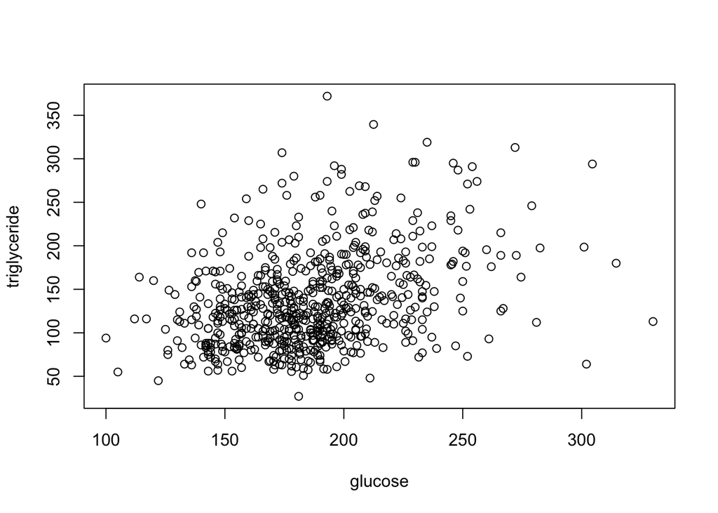

```r
glucose <- cc_data$GLU
triglyceride <- cc_data$TG
plot(x = glucose, y = triglyceride)
```

Create a linear model of triglyceride as a response to glucose levels. Call the lm function by providing a formula and data.

```r
lm(formula = triglyceride ~ glucose, data = cc_data)
```

```
##
## Call:
## lm(formula = triglyceride ~ glucose, data = cc_data)
##
## Coefficients:
## (Intercept)      glucose
##     30.4762       0.5686
```

The lm function repeats the call that you made, then provides model coefficients. This model provides parameters alpha (intercept) near 30.5, and beta of 0.5686. These are the parameters that minimize the sum of squared errors. In plain English, the model states that for every 1 unit increase in glucose, there’s approximately a 1/2 unit increase in triglyceride starting from a value of 30.5. So, when glucose equals zero, triglyceride is approximately 30.5. When glucose has a value of 1, triglyceride has a value near 31, and so on.

Is it reasonable for glucose to have a value of zero? No. The alpha term or intercept is a starting point and doesn’t have meaning beyond that.

When you call the lm function, you get very little information in return. To view all information for the model, save the model as a variable.

```r
model <- lm(formula = triglyceride ~ glucose, data = cc_data)
```

Plot the regression line in a scatterplot.

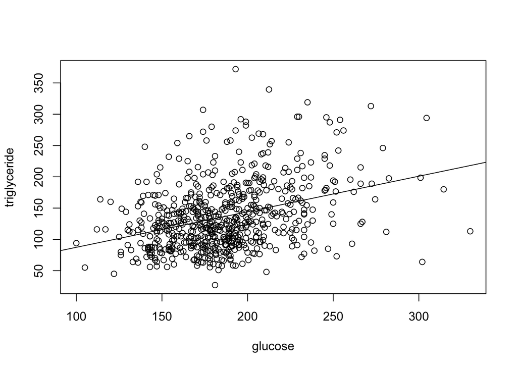

```r
plot(x = glucose, y = triglyceride)
abline(model)
```

#### Understanding model significance and quality

You can obtain more information about the model with the summary function. This will give you alpha and beta parameters, and useful information for evaluating model fit, quality, and significance.

```r
summary(model)
```

```
##
## Call:
## lm(formula = triglyceride ~ glucose, data = cc_data)
##
## Residuals:
##      Min       1Q   Median       3Q      Max
## -138.190  -35.905   -6.784   25.931  231.786
##
## Coefficients:
##             Estimate Std. Error t value Pr(>|t|)
## (Intercept) 30.47618   11.56944   2.634  0.00864 **
## glucose      0.56859    0.06122   9.287  < 2e-16 ***
## ---
## Signif. codes:  0 '***' 0.001 '**' 0.01 '*' 0.05 '.' 0.1 ' ' 1
##
## Residual standard error: 50.82 on 628 degrees of freedom
##   (12 observations deleted due to missingness)
## Multiple R-squared:  0.1208, Adjusted R-squared:  0.1194
## F-statistic: 86.25 on 1 and 628 DF,  p-value: < 2.2e-16
```

The first item to inspect is the last item in the summary, the F-statistic. The F-statistic indicates whether or not the model is significant. If the model is not significant, there’s no point in examining the rest. By convention a p-value of .05 or less indicates significance, or alternatively a likelihood of .05 or less that the model is not significant. This model has a p-value very close to zero.

The R squared value provides a measure of correlation and the fraction of the variance of y that is explained by the model. This indicates the usefulness and quality of the model.

The summary repeats the call you made to the lm function. This is followed by the quartile values for the residuals, which serves as a quick check on the distribution of the residuals. The average of the residuals is assumed to be zero, so the median value should not be too far from zero. The minimum and maximum values can indicate outliers. Otherwise, minimum and maximum should have approximately equal absolute values. Check that the residuals are normally distributed by creating a histogram and a Q-Q plot.

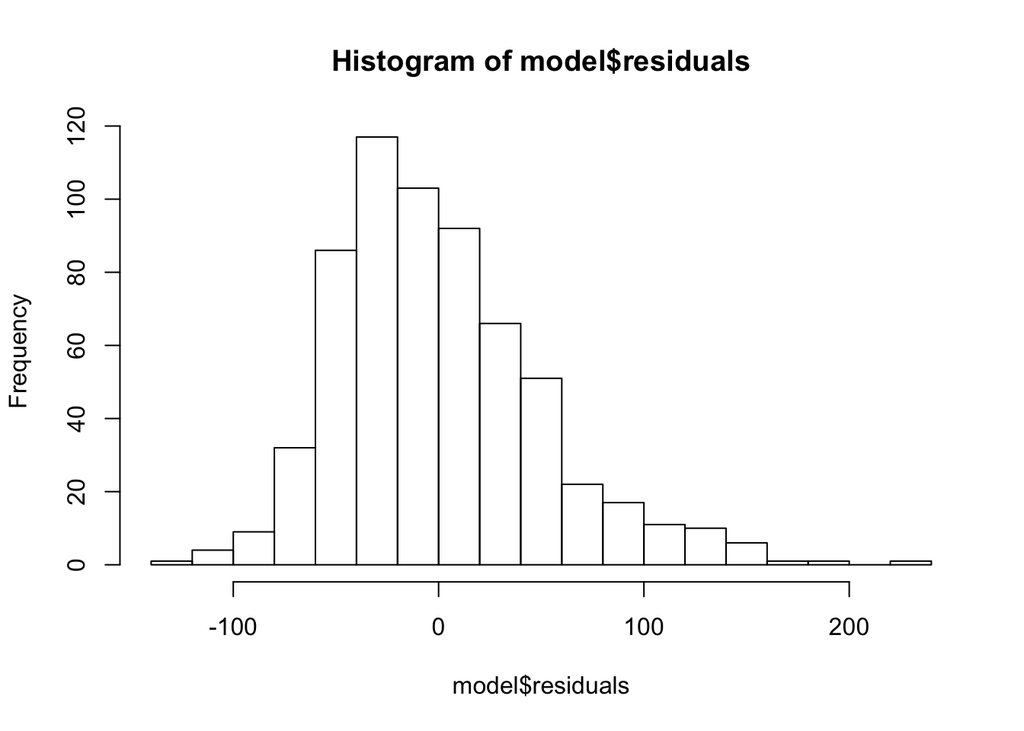

```r
hist(x = model$residuals, breaks=20)
```

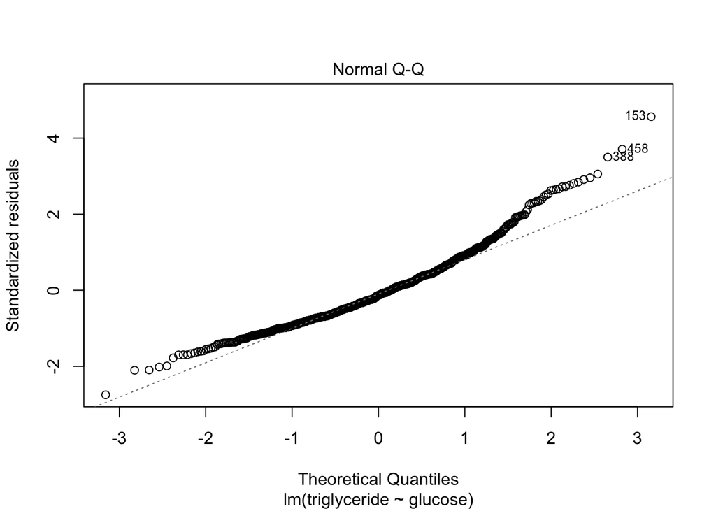

```r
plot(model, which=2)
```

The Q-Q plot indicates 3 data points that stand out. Index numbers are supplied for each. Otherwise, most of the points lie along the diagonal line, indicating that the residuals are normally distributed.

Back to the model summary. After a quick preview of the distribution of residuals, estimates of model coefficients are given along with standard error, t-test, and p-values for each. The asterisks indicate significance, such that a single asterisk indicates a p-value between 0.01 and 0.05. The standard error for each coefficient can be used to compute confidence intervals for each and to test whether a coefficient has a specific value. The residual standard error indicates the variation of the observations around the regression line.

Plot the residuals against fitted values from the model. They should be well-scattered and should not form a curve such as a parabola, which would indicate that a quadratic, not a linear model, better fits the data. There should be constant variance vertically and points should scatter symmetrically around zero.

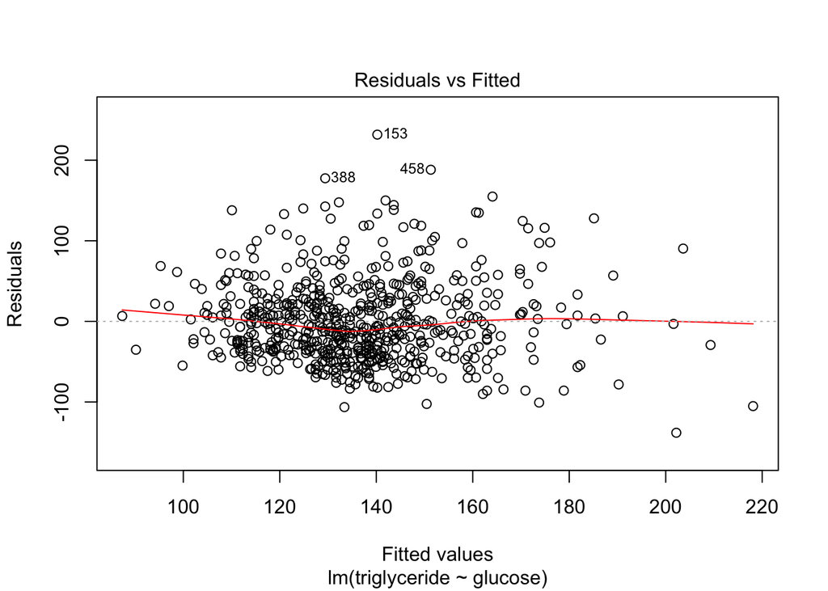

```r
plot(model, which=1)
```

Building linear models with R is straightforward, however, judging their significance and usefulness is not. The F-statistic indicates whether the model is statistically significant. The t statistics and p-values for the coefficients indicate their significance. The R squared value indicates usefulness and quality of the model by providing the fraction of the variance of y that is explained by the model, as well as the correlation. A plot of the residuals against fitted values indicates whether the model fits the data well, or whether some other kind of model would do better. Ultimately it’s up to you to judge the significance, quality and fit of a linear model.

Let’s look at one that is unmistakably good. Create a linear model of high-density lipoprotein (HDL) and cholesterol. HDL is a form of cholesterol, so essentially we’re modeling one variable against itself.

```r
good_model <- lm(formula = HDL ~ CHOL, data = cc_data)
```

Plot the regression line in a scatterplot.

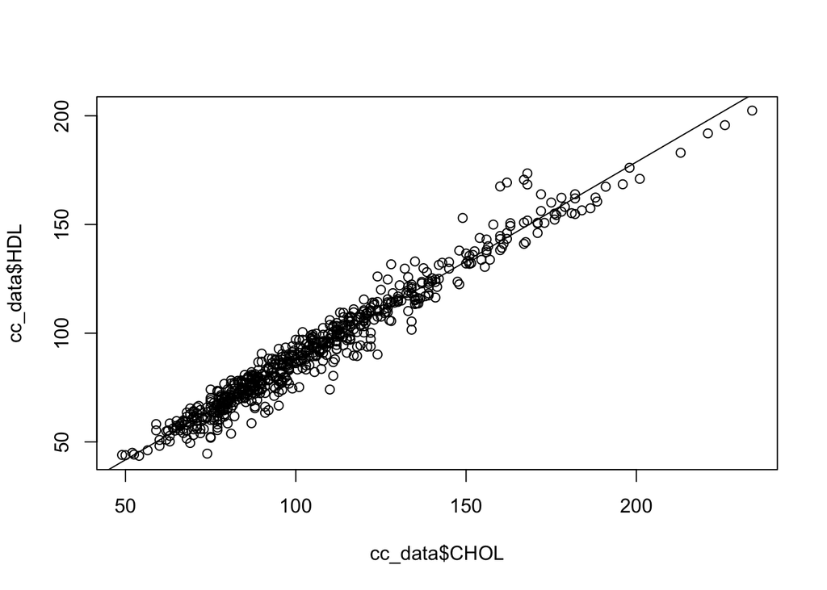

```r
plot(x = cc_data$CHOL, y = cc_data$HDL)
abline(good_model)
```

```r
summary(good_model)
```

```
##
## Call:
## lm(formula = HDL ~ CHOL, data = cc_data)
##
## Residuals:
##      Min       1Q   Median       3Q      Max
## -22.4644  -2.8952   0.2715   3.2565  25.2802
##
## Coefficients:
##              Estimate Std. Error t value Pr(>|t|)
## (Intercept) -3.877334   0.826344  -4.692 3.32e-06 ***
## CHOL         0.913107   0.007525 121.341  < 2e-16 ***
## ---
## Signif. codes:  0 '***' 0.001 '**' 0.01 '*' 0.05 '.' 0.1 ' ' 1
##
## Residual standard error: 5.779 on 628 degrees of freedom
##   (12 observations deleted due to missingness)
## Multiple R-squared:  0.9591, Adjusted R-squared:  0.959
## F-statistic: 1.472e+04 on 1 and 628 DF,  p-value: < 2.2e-16
```

Note the values for the F-statistic and the R-squared.

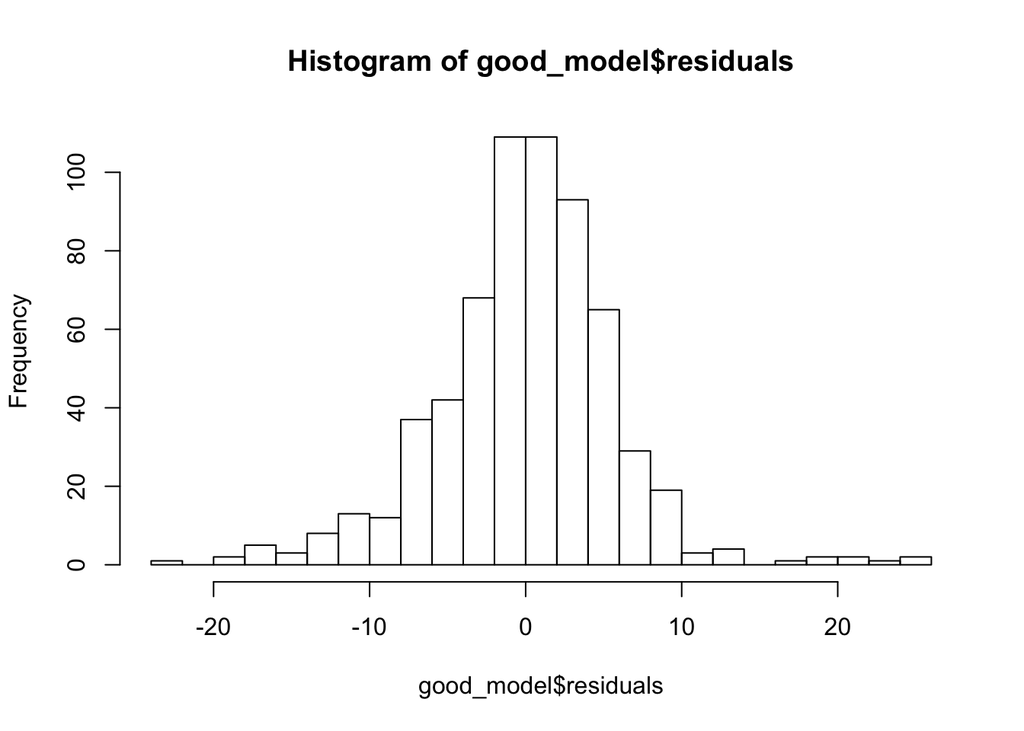

```r
hist(x = good_model$residuals, breaks=20)
```

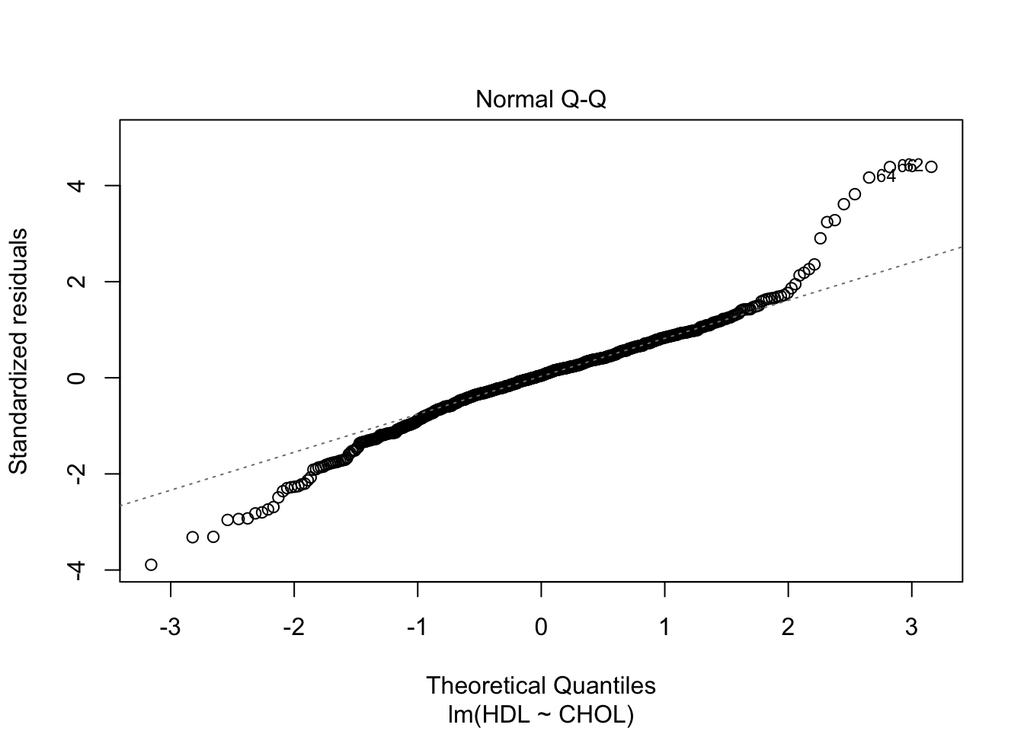

```r
plot(good_model, which=2)
```

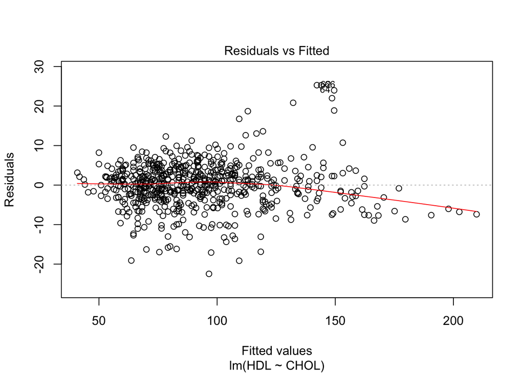

```r
plot(good_model, which=1)
```

Now let’s look at one that is unmistakably bad. Create a linear model of hemoglobin concentration distribution width (HDW) and bone area.

```r
bad_model <- lm(formula = HDW ~ bone_area, data = cc_data)
```

Plot the regression line in a scatterplot.

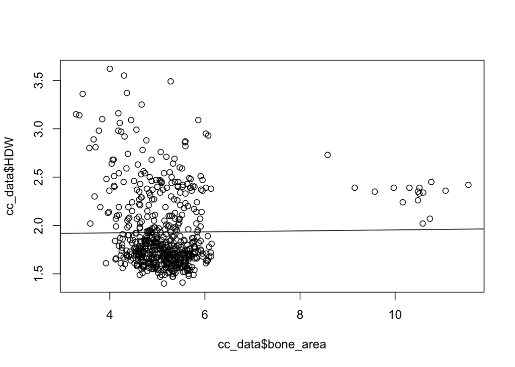

```r
plot(x = cc_data$bone_area, y = cc_data$HDW)
abline(bad_model)
```

```r
summary(bad_model)
```

```
##
## Call:
## lm(formula = HDW ~ bone_area, data = cc_data)
##
## Residuals:
##     Min      1Q  Median      3Q     Max
## -0.5296 -0.2630 -0.1530  0.1712  1.6964
##
## Coefficients:
##             Estimate Std. Error t value Pr(>|t|)
## (Intercept) 1.902727   0.085920  22.145   <2e-16 ***
## bone_area   0.005231   0.016195   0.323    0.747
## ---
## Signif. codes:  0 '***' 0.001 '**' 0.01 '*' 0.05 '.' 0.1 ' ' 1
##
## Residual standard error: 0.395 on 576 degrees of freedom
##   (64 observations deleted due to missingness)
## Multiple R-squared:  0.0001811,  Adjusted R-squared:  -0.001555
## F-statistic: 0.1043 on 1 and 576 DF,  p-value: 0.7468
```

Note the values for the F-statistic and the R-squared. Also notice that beta, the slope, is near zero, indicating no relationship between the two variables.

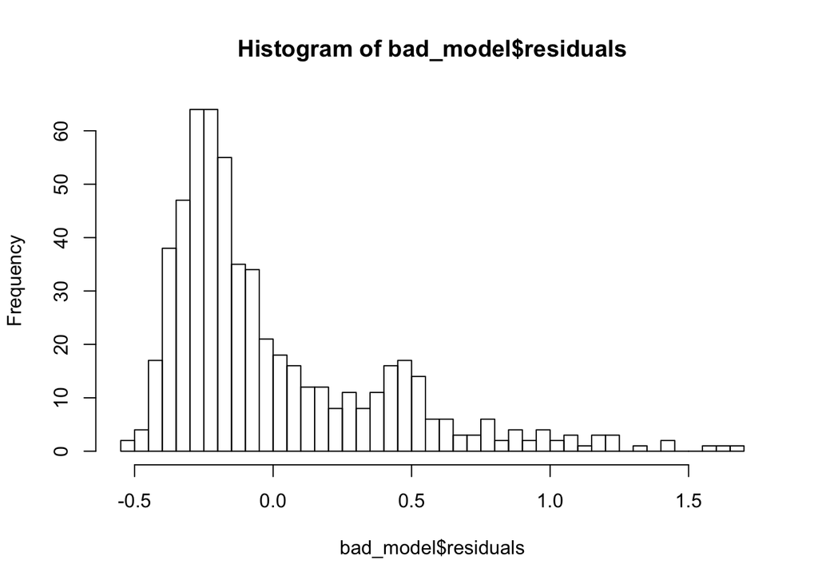

```r
hist(x = bad_model$residuals, breaks=40)
```

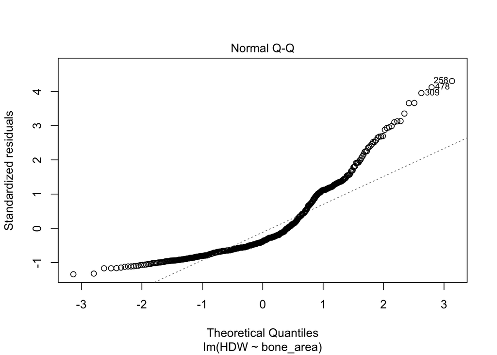

```r
plot(bad_model, which=2)
```

The histogram doesn’t show a normal distribition, and mean residual value doesn’t appear to be near zero. In the Q-Q plot most of the data points are off-diagonal.

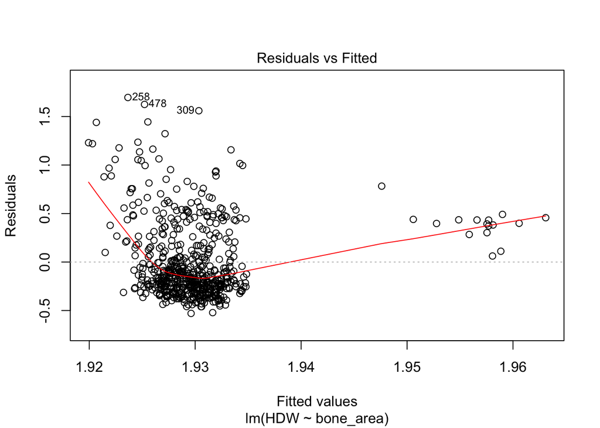

```r
plot(bad_model, which=1)
```

The plot of residuals vs. fitted values appears parabolic, indicating poor model fit.